# Compound Annotation

Mar Garcia-Aloy, Pietro Franceschi

```r
library(MetaboCoreUtils)
library(xcms)
library(MsExperiment)
library(MetaboAnnotation)
library(Spectra)
library(tidyverse)
library(plotly)
```

## Introduction

The objective of this demo is to perform compound annotation based on an in-house database, created with the information gathered from the injection of a series of authentic standards with the same analytical protocol used for the samples. For that we will use the file from “mix 2”, which contains the following compounds:

- Malvidin-3,5-diglucoside, C29H35O17+
- Quercitrin-3-rhamnoside, C21H20O11
- Laricitrin, C16H12O8
- Quercetin-3-galactoside, C21H20O12
- o-Coumaric acid, C9H8O3
- Gallic acid, C7H6O5
- Procyanidin B3, C30H26O12
- Procyanidin A2, C30H24O12

## Create the in-house library

The first step is to create our library with the information of the standards. For that, we create a reference database with the m/z values of the [M-H]<sup>-</sup> ion, which is the most common ion we see with our analytical setup.

```r
stds_tb <- data.frame(
  name = c("Malvidin-3,5-diglucoside", "Quercitrin-3-rhamnoside", "Laricitrin",
           "Quercetin-3-galactoside", "o-Coumaric acid", "Gallic acid",
           "Procyanidin B3", "Procyanidin A2"),
  formula = c("C29H34O17", "C21H20O11", "C16H12O8", "C21H20O12",
              "C9H8O3", "C7H6O5", "C30H26O12", "C30H24O12")
)
```

To calculate masses and m/z values we use the functions of the package [`MetaboCoreUtils`](https://bioconductor.org/packages/release/bioc/html/MetaboCoreUtils.html):

```r
stds_tb$mass <- calculateMass(stds_tb$formula)
stds_tb$mz <- as.numeric(mass2mz(stds_tb$mass, "[M-H]-"))
stds_tb
```

```
##                       name   formula     mass       mz
## 1 Malvidin-3,5-diglucoside C29H34O17 654.1796 653.1723
## 2  Quercitrin-3-rhamnoside C21H20O11 448.1006 447.0933
## 3               Laricitrin  C16H12O8 332.0532 331.0459
## 4  Quercetin-3-galactoside C21H20O12 464.0955 463.0882
## 5          o-Coumaric acid    C9H8O3 164.0473 163.0401
## 6              Gallic acid    C7H6O5 170.0215 169.0142
## 7           Procyanidin B3 C30H26O12 578.1424 577.1352
## 8           Procyanidin A2 C30H24O12 576.1268 575.1195
```

Here we have the table with the theoretical m/z values that we expect to find in the injection of the standards.

The next step is to determine their retention times. For that, we do chromatographic peak detection in the file of the injection of the standards.

```r
## import the file
std_files <- list.files("../data/wines/", pattern = "mix02", full.names = TRUE)
std_raw <- readMsExperiment(spectraFiles = std_files) |>
  filterMsLevel(1)   ## only full scan

## peak picking
cwp <- CentWaveParam(peakwidth = c(5, 30),    ## expected range of chromatographic peak width
                     ppm = 5,                 ## tolerance to identify ROIs in the mz/rt plane
                     prefilter = c(5, 50000), ## at least 5 consecutive scans with a signal higher than 50000
                     noise = 5000)
register(SerialParam()) ## setting xcms in serial mode
std_cw <- findChromPeaks(std_raw, param = cwp)

std_pks <- chromPeaks(std_cw)
std_pks[1:20, ]
```

```
##             mz    mzmin    mzmax       rt    rtmin    rtmax       into
## CP001 149.0093 149.0092 149.0093  53.8847  48.8753  63.7131   697822.7
## CP002 125.0246 125.0246 125.0247  53.8847  50.5242  62.5046  1318548.2
## CP003 169.0143 169.0142 169.0143  53.8847  50.5242  62.5046  2680096.3
## CP004 125.0246 125.0246 125.0247  92.5009  87.5114  98.7116  1693969.3
## CP005 169.0143 169.0143 169.0143  92.5009  87.5114  98.7116  3974028.5
## CP006 671.1821 671.1816 671.1826 239.6843 230.2282 246.7447  1232615.2
## CP007 577.1345 577.1341 577.1346 242.1512 236.1621 249.6089  2084341.7
## CP008 576.1225 576.1222 576.1226 332.4844 328.3678 339.8243  1655915.2
## CP009 673.0962 673.0956 673.0970 333.6979 327.1548 339.8243  1933358.1
## CP010 463.0878 463.0874 463.0879 327.1548 322.4942 332.4844 12252034.8
## CP011 575.1190 575.1188 575.1194 333.6979 327.1548 343.9343  5355539.0
## CP012 447.0929 447.0928 447.0930 353.9643 349.3436 358.9049 12208440.3
## CP013 163.0402 163.0402 163.0404 367.2148 362.6492 372.9214  5967046.6
## CP014 119.0505 119.0502 119.0505 367.2148 362.6492 372.9214 11531168.8
## CP015 512.9748 512.9739 512.9755 427.0952 422.7647 432.9044   650018.4
## CP016 316.0223 316.0222 316.0224 425.6146 422.7647 432.9044  1771609.1
## CP017 332.0489 332.0488 332.0490 425.6146 422.7647 432.9044  3384154.4
## CP018 446.8049 446.8040 446.8057 444.8943 440.7818 450.9610   627985.4
## CP019 446.8058 446.8046 446.8073 427.0952 422.7647 429.9842   330081.9
## CP020 446.8051 446.8041 446.8056 435.3639 429.9842 440.7818   622210.4
##             intb       maxo     sn sample
## CP001   697809.5   86023.87  86023      1
## CP002  1289315.0  203597.83     31      1
## CP003  2555866.1  390782.22     20      1
## CP004  1654649.3  214933.00     32      1
## CP005  3928392.4  559039.25     36      1
## CP006  1225886.0  116713.79     49      1
## CP007  2084326.7  331704.12 331703      1
## CP008  1655903.7  289461.31 289460      1
## CP009  1928776.5  320353.97    160      1
## CP010 12242768.7 3713274.75   1014      1
## CP011  5355522.2  845166.75 845166      1
## CP012 12184820.4 3936981.00    360      1
## CP013  5960745.1 1597530.25    699      1
## CP014 11515166.4 3122588.00    890      1
## CP015   647257.8  129739.85     54      1
## CP016  1770159.7  368829.16    339      1
## CP017  3363959.3  670717.19    134      1
## CP018   627973.7   66919.57  66919      1
## CP019   330074.7   49702.32  49701      1
## CP020   622198.3   62317.11  62316      1
```

In total 104 chromatographic peaks have been identified. This is much more than what we would expect, since the sample is a mixture of 8 pure standards … Do you have any idea that could explain why the number of peaks is so much larger than the number of compounds in this sample?

We now annotate these chromatographic peaks using only their m/z values. For that we use the functions of the package [`MetaboAnnotation`](https://bioconductor.org/packages/release/bioc/html/MetaboAnnotation.html). To annotate the detected peaks we use the function `matchMz()` against the reference database we have just created:

```r
pks_match <- matchMz(
  std_pks, stds_tb, param = MzParam(ppm = 10)
)
pks_match
```

```
## Object of class Matched
## Total number of matches: 8
## Number of query objects: 104 (8 matched)
## Number of target objects: 8 (7 matched)
```

The result object handles the potential many-to-many matching between chromatographic peaks (*query*) and reference compounds (*target*), and contains all the information of both the query and the target objects, together with the score of the match (in this case the difference between the m/z values). For example, here we can see that 7 of the 8 reference compounds were found among the detected chromatographic peaks. We can extract the full matching table with the function `matchedData()`. This returns a table with all the queries (i.e., chromatographic peaks) in the rows and the corresponding matches in the columns whose names start with “target_”. If a query (i.e., chromatographic peak) matches more than one element of the target (i.e., reference database), its row is duplicated in the returned table. For the rows that cannot be matched NA values are reported.

```r
tb_match <- matchedData(pks_match)
tb_match
```

```
## DataFrame with 104 rows and 17 columns
##              mz     mzmin     mzmax        rt     rtmin     rtmax      into
##       <numeric> <numeric> <numeric> <numeric> <numeric> <numeric> <numeric>
## CP001   149.009   149.009   149.009   53.8847   48.8753   63.7131    697823
## CP002   125.025   125.025   125.025   53.8847   50.5242   62.5046   1318548
## CP003   169.014   169.014   169.014   53.8847   50.5242   62.5046   2680096
## CP004   125.025   125.025   125.025   92.5009   87.5114   98.7116   1693969
## CP005   169.014   169.014   169.014   92.5009   87.5114   98.7116   3974028
## ...         ...       ...       ...       ...       ...       ...       ...
## CP100   288.936   288.936   288.936   718.178   714.144   719.685   2064367
## CP101   294.902   294.902   294.902   718.178   712.868   719.685    964329
## CP102   304.914   304.914   304.914   718.178   714.144   719.685   1962710
## CP103   311.168   311.168   311.168   699.506   685.236   718.178  11637225
## CP104   312.172   312.171   312.172   699.506   681.960   718.178   2287416
##            intb      maxo        sn    sample   target_name target_formula
##       <numeric> <numeric> <numeric> <numeric>   <character>    <character>
## CP001    697809   86023.9     86023         1            NA             NA
## CP002   1289315  203597.8        31         1            NA             NA
## CP003   2555866  390782.2        20         1 Gallic aci...         C7H6O5
## CP004   1654649  214933.0        32         1            NA             NA
## CP005   3928392  559039.2        36         1 Gallic aci...         C7H6O5
## ...         ...       ...       ...       ...           ...            ...
## CP100   2051862    651686       134         1            NA             NA
## CP101    934061    200990        32         1            NA             NA
## CP102   1943342    681089       113         1            NA             NA
## CP103  11454235    597291        74         1            NA             NA
## CP104   2240545    122710        32         1            NA             NA
##       target_mass target_mz       score ppm_error
##         <numeric> <numeric>   <numeric> <numeric>
## CP001          NA        NA          NA        NA
## CP002          NA        NA          NA        NA
## CP003     170.022   169.014 1.12462e-05 0.0665399
## CP004          NA        NA          NA        NA
## CP005     170.022   169.014 4.79129e-05 0.2834846
## ...           ...       ...         ...       ...
## CP100          NA        NA          NA        NA
## CP101          NA        NA          NA        NA
## CP102          NA        NA          NA        NA
## CP103          NA        NA          NA        NA
## CP104          NA        NA          NA        NA
```

Not all chromatographic peaks were annotated, while in other cases more than one chromatographic peak was assigned to the same compound. Let’s keep only the annotated chromatographic peaks:

```r
tb_match <- tb_match[!is.na(tb_match$target_name), ]
tb_match
```

```
## DataFrame with 8 rows and 17 columns
##              mz     mzmin     mzmax        rt     rtmin     rtmax      into
##       <numeric> <numeric> <numeric> <numeric> <numeric> <numeric> <numeric>
## CP003   169.014   169.014   169.014   53.8847   50.5242   62.5046   2680096
## CP005   169.014   169.014   169.014   92.5009   87.5114   98.7116   3974028
## CP007   577.134   577.134   577.135  242.1512  236.1621  249.6089   2084342
## CP010   463.088   463.087   463.088  327.1548  322.4942  332.4844  12252035
## CP011   575.119   575.119   575.119  333.6979  327.1548  343.9343   5355539
## CP012   447.093   447.093   447.093  353.9643  349.3436  358.9049  12208440
## CP013   163.040   163.040   163.040  367.2148  362.6492  372.9214   5967047
## CP022   331.046   331.046   331.046  425.6146  421.1173  432.9044  19778108
##            intb      maxo        sn    sample   target_name target_formula
##       <numeric> <numeric> <numeric> <numeric>   <character>    <character>
## CP003   2555866    390782        20         1 Gallic aci...         C7H6O5
## CP005   3928392    559039        36         1 Gallic aci...         C7H6O5
## CP007   2084327    331704    331703         1 Procyanidi...      C30H26O12
## CP010  12242769   3713275      1014         1 Quercetin-...      C21H20O12
## CP011   5355522    845167    845166         1 Procyanidi...      C30H24O12
## CP012  12184820   3936981       360         1 Quercitrin...      C21H20O11
## CP013   5960745   1597530       699         1 o-Coumaric...         C9H8O3
## CP022  19699822   3990305       376         1    Laricitrin       C16H12O8
##       target_mass target_mz        score ppm_error
##         <numeric> <numeric>    <numeric> <numeric>
## CP003     170.022   169.014  1.12462e-05 0.0665399
## CP005     170.022   169.014  4.79129e-05 0.2834846
## CP007     578.142   577.135 -6.91385e-04 1.1979599
## CP010     464.095   463.088 -4.35508e-04 0.9404437
## CP011     576.127   575.120 -4.71652e-04 0.8200931
## CP012     448.101   447.093 -4.23341e-04 0.9468739
## CP013     164.047   163.040  1.12839e-04 0.6920949
## CP022     332.053   331.046 -3.20979e-04 0.9695903
```

Column “score” gives the difference between the query and the target m/z values (in Da) and “ppm_error” the error in ppm. As you can see, gallic acid was annotated twice, while malvidin-3,5-diglucoside was not detected. The second case was expected, since anthocyanins are positively charged and do not ionize well in negative ion mode. When a compound is annotated more than once, we keep the chromatographic peak with the highest intensity.

```r
tb_match <- tb_match[order(tb_match$maxo, decreasing = TRUE), ]
tb_match <- tb_match[!duplicated(tb_match$target_name), ]
```

At this point we can add to our reference database the retention time of each analytical standard:

```r
stds_tb$RT <- tb_match$rt[match(stds_tb$name, tb_match$target_name)]
stds_tb
```

```
##                       name   formula     mass       mz       RT
## 1 Malvidin-3,5-diglucoside C29H34O17 654.1796 653.1723       NA
## 2  Quercitrin-3-rhamnoside C21H20O11 448.1006 447.0933 353.9643
## 3               Laricitrin  C16H12O8 332.0532 331.0459 425.6146
## 4  Quercetin-3-galactoside C21H20O12 464.0955 463.0882 327.1548
## 5          o-Coumaric acid    C9H8O3 164.0473 163.0401 367.2148
## 6              Gallic acid    C7H6O5 170.0215 169.0142  92.5009
## 7           Procyanidin B3 C30H26O12 578.1424 577.1352 242.1512
## 8           Procyanidin A2 C30H24O12 576.1268 575.1195 333.6979
```

Finally, we check if in this injection MS/MS spectra of the standards were recorded:

```r
## load the MS/MS data
std_MSMS <- readMsExperiment(spectraFiles = std_files[1]) |>
  filterMsLevel(2)   ## only fragmentation

## create a query data.frame with the precursor m/z and retention time of each MS/MS spectrum
std_MSMS_tb <- data.frame(
  mz = precursorMz(spectra(std_MSMS)),
  rtime = rtime(spectra(std_MSMS))
)

## annotation based on the precursor m/z
MSMS_match <- matchMz(
  std_MSMS_tb, stds_tb, param = MzParam(ppm = 10)
)
MSMS_match
```

```
## Object of class Matched
## Total number of matches: 3
## Number of query objects: 522 (3 matched)
## Number of target objects: 8 (3 matched)
```

```r
MSMS_match_tb <- matchedData(MSMS_match)
MSMS_match_tb <- MSMS_match_tb[!is.na(MSMS_match_tb$target_name), ]
MSMS_match_tb
```

```
## DataFrame with 3 rows and 9 columns
##          mz     rtime   target_name target_formula target_mass target_mz
##   <numeric> <numeric>   <character>    <character>   <numeric> <numeric>
## 1   169.014   89.1859 Gallic aci...         C7H6O5     170.022   169.014
## 2   577.135  243.0483 Procyanidi...      C30H26O12     578.142   577.135
## 3   163.040  370.8306 o-Coumaric...         C9H8O3     164.047   163.040
##   target_RT        score ppm_error
##   <numeric>    <numeric> <numeric>
## 1   92.5009  3.49346e-05  0.206696
## 2  242.1512 -5.67752e-04  0.983743
## 3  367.2148  1.38793e-04  0.851283
```

In this injection MS/MS spectra were recorded for only 3 of the 8 analytical standards (Gallic acid, Procyanidin B3, o-Coumaric acid). In DDA the instrument fragments only the most intense ions of each full scan, so the other standards, even when they give a chromatographic peak, were never selected for fragmentation. Let’s keep this information: later it will be useful to compare these MS/MS spectra with the ones collected in the wine samples, to confirm their annotation with a higher confidence.

## Annotation of study samples

We are now ready to see if any of the compounds of “mix 2” are present in the study samples.

We load the processed data:

```r
load("processed_wines_data.RData")
head(feat)
```

```
##          mzmed    mzmin    mzmax     rtmed     rtmin     rtmax npeaks red wht X
## FT001 56.56990 56.56982 56.56991 274.05291 272.92031 275.30615      8   8   0 0
## FT002 59.01401 59.01395 59.01411  52.56501  51.36898  53.42346     17   6   6 5
## FT003 65.67792 65.67789 65.67797  61.27596  60.28428  69.03806     10   9   0 0
## FT004 65.67793 65.67791 65.67794  79.48278  78.58837  80.35275      9   9   0 0
## FT005 68.45647 68.45641 68.45649 182.16756 180.08132 183.31498     17   3   8 6
## FT006 68.45646 68.45642 68.45648 163.10147 161.28544 171.09788     10   2   2 6
##            peakidx ms_level
## FT001 1875, 25....        1
## FT002 405, 730....        1
## FT003 1546, 28....        1
## FT004 1545, 28....        1
## FT005 292, 101....        1
## FT006 293, 101....        1
```

We annotate the features with our reference table, using this time both m/z and retention time, with the functions `matchValues()` and `MzRtParam()`.

```r
ft_match <- matchValues(
  feat, stds_tb, param = MzRtParam(ppm = 10, toleranceRt = 5),
  mzColname = c("mzmed", "mz"),
  rtColname = c("rtmed", "RT")
)
ft_match
```

```
## Object of class Matched
## Total number of matches: 4
## Number of query objects: 734 (4 matched)
## Number of target objects: 8 (4 matched)
```

Let’s see which compounds were found:

```r
ft_tb_match <- matchedData(ft_match)
ft_tb_match <- ft_tb_match[!is.na(ft_tb_match$target_name), ]
ft_tb_match
```

```
## DataFrame with 4 rows and 20 columns
##           mzmed     mzmin     mzmax     rtmed     rtmin     rtmax    npeaks
##       <numeric> <numeric> <numeric> <numeric> <numeric> <numeric> <numeric>
## FT168   169.014   169.014   169.014   91.7115   91.0963    93.199        26
## FT478   331.045   331.045   331.045  426.7485  425.6656   427.273        16
## FT637   463.087   463.087   463.089  327.8480  324.8748   337.802        16
## FT690   577.134   577.133   577.135  244.1341  243.3218   245.450        12
##             red       wht         X            peakidx  ms_level   target_name
##       <numeric> <numeric> <numeric>             <list> <integer>   <character>
## FT168        10        10         6  306,1023,1743,...         1 Gallic aci...
## FT478        10         0         6  620,1368,2055,...         1    Laricitrin
## FT637         7         2         6  530,1260,1967,...         1 Quercetin-...
## FT690         5         2         5  480,1209,2619,...         1 Procyanidi...
##       target_formula target_mass target_mz target_RT        score ppm_error
##          <character>   <numeric> <numeric> <numeric>    <numeric> <numeric>
## FT168         C7H6O5     170.022   169.014   92.5009 -6.31429e-05  0.373595
## FT478       C16H12O8     332.053   331.046  425.6146 -8.03120e-04  2.426009
## FT637      C21H20O12     464.095   463.088  327.1548 -9.31859e-04  2.012271
## FT690      C30H26O12     578.142   577.135  242.1512 -1.59914e-03  2.770823
##        score_rt
##       <numeric>
## FT168 -0.789424
## FT478  1.133945
## FT637  0.693214
## FT690  1.982916
```

Considering both m/z and retention time, 4 of the 8 compounds of mix 2 are observed in the wine samples: Gallic acid, Laricitrin, Quercetin-3-galactoside, Procyanidin B3.

Below we plot the feature of gallic acid in the study samples, with a vertical line at the retention time of the analytical standard:

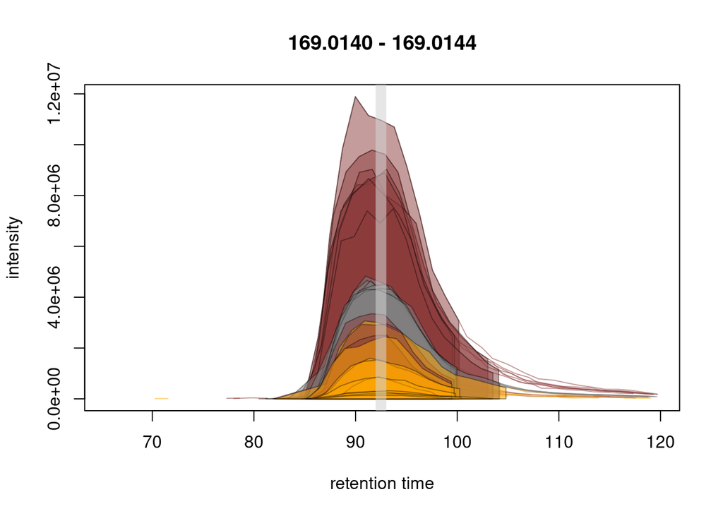

```r
gallic_acid <- stds_tb[stds_tb$name == "Gallic acid", ]
ga_feature <- rownames(ft_tb_match)[ft_tb_match$target_name == "Gallic acid"]

ft_chr <- featureChromatograms(raw_data_filled,
                               features = ga_feature,
                               expandRt = 15,
                               filled = FALSE)
sample_colors <- c(red = "#8B3A3A80", wht = "#FFA50080", X = "#80808080")[sampleData(raw_data_filled)$color]
plot(ft_chr, col = sample_colors,
     peakBg = sample_colors[chromPeaks(ft_chr)[, "sample"]])
abline(v = gallic_acid$RT, lwd = 10, col = "#D2D2D290")
```

Finally, let’s compare the MS/MS spectrum of gallic acid recorded in the analytical standard with the MS/MS spectra of this feature recorded in the study samples:

```r
## the MS/MS spectrum of the standard
ga_MSMS <- std_MSMS |>
  spectra() |>
  filterPrecursorMzValues(gallic_acid$mz, ppm = 10) |>
  filterRt(gallic_acid$RT + 5 * c(-1, 1))

## all the MS/MS spectra in the study samples with the m/z and retention time of gallic acid
MSMS_data <- readMsExperiment(spectraFiles = sampleData(raw_data_filled)$filepath) |>
  filterMsLevel(2)   ## only fragmentation

ga_MSMS_data <- MSMS_data |>
  spectra() |>
  filterPrecursorMzValues(gallic_acid$mz, ppm = 10) |>
  filterRt(gallic_acid$RT + 5 * c(-1, 1))
ga_MSMS_data
```

```
## MSn data (Spectra) with 10 spectra in a MsBackendMzR backend:
##      msLevel     rtime scanIndex
##    <integer> <numeric> <integer>
## 1          2   97.4448       230
## 2          2   89.8054       212
## 3          2   94.8745       224
## 4          2   96.1294       227
## 5          2   97.1974       230
## 6          2   88.1592       209
## 7          2   96.5791       224
## 8          2   95.9035       227
## 9          2   95.5602       224
## 10         2   96.8113       227
##  ... 34 more variables/columns.
##
## file(s):
## x005_red_ptnoir_A_1_NEG_DDA.mzML
## x009_wht_chardo_B_1_NEG_DDA.mzML
## x011_red_lagrei_B_1_NEG_DDA.mzML
##  ... 4 more files
## Processing:
##  Filter: select MS level(s) 2 [Thu Nov 19 16:35:19 2026]
##  Filter: select spectra with precursor m/z matching 169.014247292 [Thu Nov 19 16:35:19 2026]
##  Filter: select retention time [87.50090000002..97.50090000002] on MS level(s)  [Thu Nov 19 16:35:19 2026]
```

In the study samples there are 10 MS/MS spectra with precursor m/z and retention time similar to the ones of gallic acid. Below we compare in a mirror plot the most intense of them (top) with the MS/MS spectrum of the analytical standard (bottom):

```r
best_sample <- which.max(precursorIntensity(ga_MSMS_data))

mirror_df <- bind_rows(
  as_tibble(peaksData(ga_MSMS_data)[[best_sample]]) |>
    mutate(spectrum = paste("wine:", basename(dataOrigin(ga_MSMS_data)[best_sample]))),
  as_tibble(peaksData(ga_MSMS)[[1]]) |>
    mutate(spectrum = "standard")
) |>
  mutate(rel_intensity = intensity / max(intensity), .by = spectrum) |>
  mutate(rel_intensity = if_else(spectrum == "standard", -rel_intensity, rel_intensity))

ggplotly(
  mirror_df |>
    ggplot(aes(x = mz, xend = mz, y = 0, yend = rel_intensity, col = spectrum)) +
    geom_segment() +
    geom_hline(yintercept = 0, col = "gray50") +
    scale_color_manual(values = c("#8B3A3A", "gray30"), name = NULL) +
    labs(x = "m/z", y = "relative intensity") +
    theme_light()
)
```

[interactive chart not shown]

## How similar are the two spectra?

Looking at the mirror plot is useful, but we would like to have a number. The most common measure of similarity between two MS/MS spectra is the *normalized dot product*: the peaks of the two spectra are matched on their m/z values and their intensities are compared. It goes from 0 (nothing in common) to 1 (identical spectra). `compareSpectra()` calculates it for all the pairs of spectra:

```r
compareSpectra(ga_MSMS_data, ga_MSMS, ppm = 10, tolerance = 0.005)
```

```
##  [1] 0.05014182 0.05263302 0.05733250 0.04766783 0.05132109 0.06386364
##  [7] 0.08047504 0.05209036 0.04418304 0.04555171
```

Mmm … the base peak (m/z 125.02, gallic acid after the loss of CO<sub>2</sub>) is the same, but the similarity is really low! Let’s look at the quality of the spectra. Two simple measures are:

- the **number of peaks**
- the **spectral entropy**: the Shannon entropy of the relative intensities of the peaks. It is 0 for a spectrum with a single peak and it grows when the signal is spread on many peaks of similar intensity … as it happens with noise

```r
spectra_quality <- \(x) tibble(
  file = basename(dataOrigin(x)),
  rt = rtime(x),
  n_peaks = lengths(x),
  base_peak = vapply(intensity(x), max, numeric(1)),
  entropy = entropy(x, normalized = FALSE)
)

spectra_quality(ga_MSMS)
```

```
## # A tibble: 1 × 5
##   file                         rt n_peaks base_peak entropy
##   <chr>                     <dbl>   <int>     <dbl>   <dbl>
## 1 x015_mix02_2_NEG_DDA.mzML  89.2     147   158834.    4.64
```

```r
spectra_quality(ga_MSMS_data)
```

```
## # A tibble: 10 × 5
##    file                                rt n_peaks base_peak entropy
##    <chr>                            <dbl>   <int>     <dbl>   <dbl>
##  1 x005_red_ptnoir_A_1_NEG_DDA.mzML  97.4     129   803987.    3.27
##  2 x009_wht_chardo_B_1_NEG_DDA.mzML  89.8     124   879247.    3.14
##  3 x009_wht_chardo_B_1_NEG_DDA.mzML  94.9     117   916640.    2.98
##  4 x009_wht_chardo_B_1_NEG_DDA.mzML  96.1     107   710143     3.27
##  5 x011_red_lagrei_B_1_NEG_DDA.mzML  97.2     140   861683.    3.27
##  6 x020_wht_gewurz_A_1_NEG_DDA.mzML  88.2     115  1155400.    2.81
##  7 x024_red_sangio_A_1_NEG_DDA.mzML  96.6     136  2602902.    2.12
##  8 x025_red_lagrei_A_1_NEG_DDA.mzML  95.9     120   834049.    3.15
##  9 x026_wht_chardo_C_1_NEG_DDA.mzML  95.6     131   689289.    3.55
## 10 x026_wht_chardo_C_1_NEG_DDA.mzML  96.8     111   591918.    3.43
```

More than 100 peaks for a small molecule like gallic acid? The spectra are centroided (the base peak at m/z 125.02 is a single point), but if we zoom on the low m/z region of the spectrum of the standard we see something strange: a band of tens of centroids, a few mDa apart, with irregular intensities

```r
peaksData(ga_MSMS)[[1]] |>
  as.data.frame() |>
  subset(mz < 52)
```

```
##          mz intensity
## 1  51.43112  6453.997
## 2  51.43356  8734.204
## 3  51.43604  8217.392
## 4  51.44405 23597.217
## 5  51.44672 16589.357
## 6  51.44985 11140.090
## 7  51.45456 29781.650
## 8  51.45891 13971.831
## 9  51.46106 17860.611
## 10 51.46314  6848.669
## 11 51.46532 14203.567
## 12 51.46873 36738.391
## 13 51.47134  8872.578
## 14 51.47425  9337.730
```

[output cut: 35 more lines]

These bands are noise: they increase the entropy of the spectra and, since they fall at different m/z in every spectrum, they make the spectra less similar to each other.

## DIY

- Check the peak shapes of the other annotated features.
- Compare the MS/MS spectra of the other annotated features for which at least one MS/MS spectrum of the standards was recorded.
- Annotate other compounds based on the standards included in mix 03 and/or mix 04:
  - MIX 03:
    - Petunidin-3-glucoside, C22H23O12+
    - Malvidin, C17H15O7+
    - Cyanidin-3,5-diglucoside, C27H31O16+
    - Syringetin-3-glucoside, C23H24O13
    - Quercetin-3-O-glucopyranoside, C21H20O12
    - Kaempferol, C15H10O6
    - Myricetin, C15H10O8
    - Cinnamic acid, C9H8O2
    - Benzoic acid, C7H6O2
    - Ellagic acid, C14H6O8
    - (+)-Catechin, C15H14O6
    - Procyanidin B2, C30H26O12
    - Malvidin-3,5-diglucoside, C29H35O17+
    - Epigallocatechin, C15H14O7
  - MIX 04:
    - Kaempferol-3-glucoside, C21H20O11
    - p-Coumaric acid, C9H8O3
    - 2,4-Dihydroxybenzoic acid, C7H6O4
    - Caffeic acid ethyl ester, C11H12O4
    - (-)-Catechin-3-O-gallate, C22H18O10
    - Epigallocatechin gallate, C22H18O11
    - (-)-Gallocatechin, C15H14O7
    - Isorhamnetin-3-rutinoside, C28H32O16
    - Procyanidin B1, C30H26O12

## A possible solution

For the last point we put all the steps we did for mix 02 in a function, which builds the library of a mix (m/z and retention time of each standard) …

```r
build_library <- \(mix_file, compounds) {
  lib <- compounds |>
    mutate(mass = calculateMass(formula),
           mz = as.numeric(mass2mz(mass, "[M-H]-")))
  pks <- readMsExperiment(spectraFiles = mix_file) |>
    filterMsLevel(1) |>
    findChromPeaks(param = cwp) |>
    chromPeaks()
  pks_match <- matchedData(matchMz(pks, as.data.frame(lib), param = MzParam(ppm = 10)))
  pks_match <- pks_match[!is.na(pks_match$target_name), ]
  pks_match <- pks_match[order(pks_match$maxo, decreasing = TRUE), ]
  pks_match <- pks_match[!duplicated(pks_match$target_name), ]
  lib |>
    mutate(RT = pks_match$rt[match(name, pks_match$target_name)])
}
```

… and we apply it to mix 04 (no anthocyanins here, so all the compounds are neutral)

```r
mix04 <- tibble(
  name = c("Kaempferol-3-glucoside", "p-Coumaric acid", "2,4-Dihydroxybenzoic acid",
           "Caffeic acid ethyl ester", "(-)-Catechin-3-O-gallate", "Epigallocatechin gallate",
           "(-)-Gallocatechin", "Isorhamnetin-3-rutinoside", "Procyanidin B1"),
  formula = c("C21H20O11", "C9H8O3", "C7H6O4", "C11H12O4", "C22H18O10", "C22H18O11",
              "C15H14O7", "C28H32O16", "C30H26O12")
)

mix04_lib <- build_library(list.files("../data/wines/", pattern = "mix04", full.names = TRUE), mix04)
mix04_lib
```

```
## # A tibble: 9 × 5
##   name                      formula    mass    mz    RT
##   <chr>                     <chr>     <dbl> <dbl> <dbl>
## 1 Kaempferol-3-glucoside    C21H20O11  448.  447.  351.
## 2 p-Coumaric acid           C9H8O3     164.  163.  317.
## 3 2,4-Dihydroxybenzoic acid C7H6O4     154.  153.  271.
## 4 Caffeic acid ethyl ester  C11H12O4   208.  207.  440.
## 5 (-)-Catechin-3-O-gallate  C22H18O10  442.  441.  332.
## 6 Epigallocatechin gallate  C22H18O11  458.  457.  287.
## 7 (-)-Gallocatechin         C15H14O7   306.  305.  155.
## 8 Isorhamnetin-3-rutinoside C28H32O16  624.  623.   NA
## 9 Procyanidin B1            C30H26O12  578.  577.  234.
```

Now we can annotate the features of the wines

```r
mix04_match <- matchValues(
  feat, as.data.frame(mix04_lib |> filter(!is.na(RT))),
  param = MzRtParam(ppm = 10, toleranceRt = 5),
  mzColname = c("mzmed", "mz"),
  rtColname = c("rtmed", "RT")
)

mix04_tb <- matchedData(mix04_match)
mix04_tb <- mix04_tb[!is.na(mix04_tb$target_name), ]
mix04_tb[, c("mzmed", "rtmed", "target_name", "target_RT", "ppm_error")]
```

```
## DataFrame with 4 rows and 5 columns
##           mzmed     rtmed   target_name target_RT ppm_error
##       <numeric> <numeric>   <character> <numeric> <numeric>
## FT157   163.040   316.766 p-Coumaric...   316.789  0.708966
## FT255   207.066   440.470 Caffeic ac...   440.128  1.218147
## FT407   305.066   155.691 (-)-Galloc...   154.638  1.100331
## FT688   577.133   233.856 Procyanidi...   233.987  2.943994
```

Note that three compounds of mix 04 are isomers of compounds of mix 02: they have the same formula and the same m/z

```r
isomers <- inner_join(stds_tb |> select(name, formula, RT),
                      mix04_lib |> select(name, formula, RT),
                      by = "formula", suffix = c("_mix02", "_mix04")) |>
  mutate(delta_RT = abs(RT_mix02 - RT_mix04))
isomers
```

```
##                name_mix02   formula RT_mix02             name_mix04 RT_mix04
## 1 Quercitrin-3-rhamnoside C21H20O11 353.9643 Kaempferol-3-glucoside 351.0269
## 2         o-Coumaric acid    C9H8O3 367.2148        p-Coumaric acid 316.7893
## 3          Procyanidin B3 C30H26O12 242.1512         Procyanidin B1 233.9871
##   delta_RT
## 1   2.9374
## 2  50.4255
## 3   8.1641
```

Here m/z alone is not enough, and the retention time has to do the job. It works for the pairs which elute far apart (more than the 5 s tolerance we used for the matching), but Quercitrin-3-rhamnoside and Kaempferol-3-glucoside elute only 2.9 s apart: a feature at that m/z and retention time could be either of them, and only the MS/MS spectrum could help.